# Which ratios determine growth rate?

Andrew Irwin

2021-04-19

# Growth rate estimated by regression

Use glmnet to get sparse regression to test which macromolecules (ratios, products) best predict growth rate.

Read data

```r
# liefer <- read_csv("liefer-growth-data.csv") %>% clean_names()
liefer <- read_csv("liefer-estimated-derivatives.csv") %>% clean_names()
liefer <- liefer %>% group_by(species, replicate) %>%
  replace_na(list(dilution_factor = 1 )) %>%
  mutate(dilution = cumprod(dilution_factor),
         cells = cell_density/dilution)
```

Plot, with a focus on growth rate and quota, macromolecules.

The traditional model for growth rate, at least at equilibrium, is

$$\mu = \mu_{max}\left(1 - \frac{Q_{min}}{Q}\right)$$
where Q is the cell content (quota) of a limiting resource. In these experiments that is nitrogen.

So the first plot shows growth rate as a function of 1/N (nitrogen per cell). The RNA/protein ratio is thought to be important too, so I’m showing that as well.

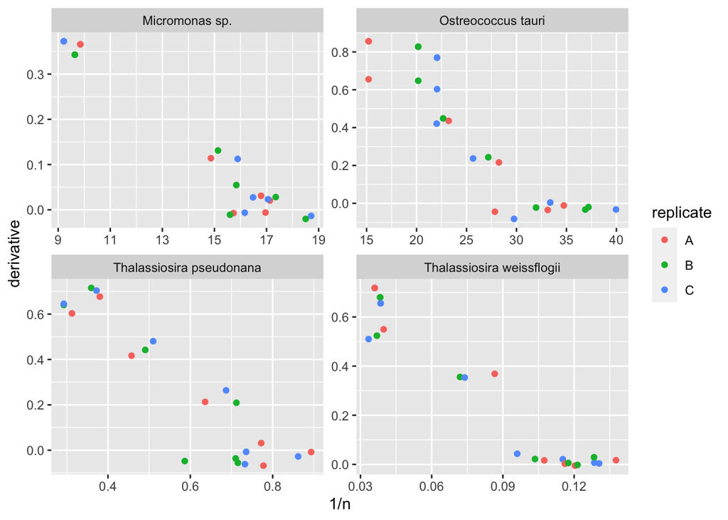

```r
liefer %>% ggplot(aes(x = 1/n,
                      y = derivative, # growth_rate,
                      color = replicate)) +
  facet_wrap( ~ species, scale="free") +
  geom_point()
```

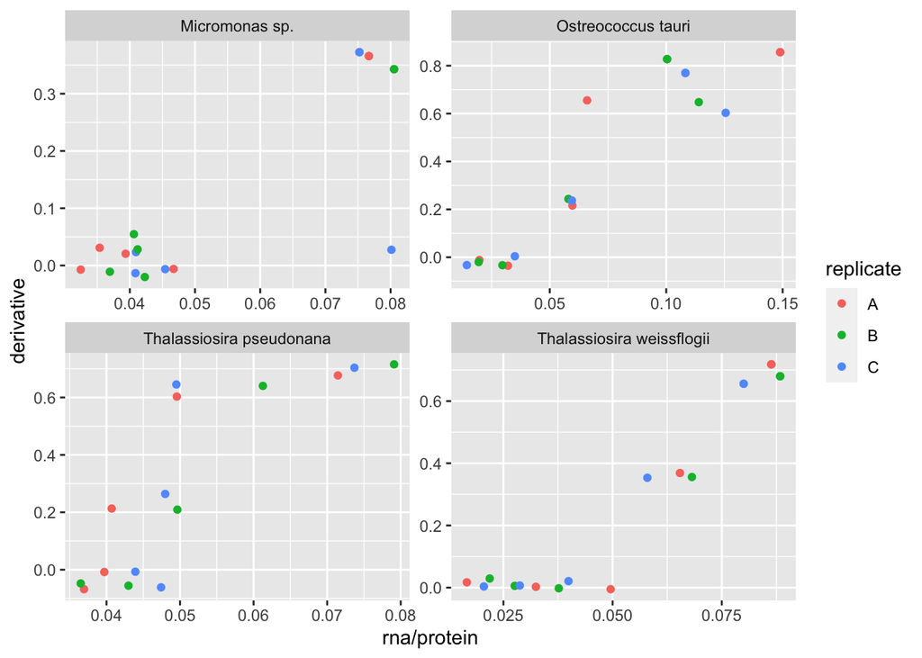

```r
liefer %>% ggplot(aes(x = rna/protein,
                      y = derivative, # growth_rate,
                      color = replicate)) +
  facet_wrap( ~ species, scale="free") +
  geom_point()
```

## Sample calculation

Use glmnet to fit a model. Prepare the response and design matrix. Just do one replicate for now.

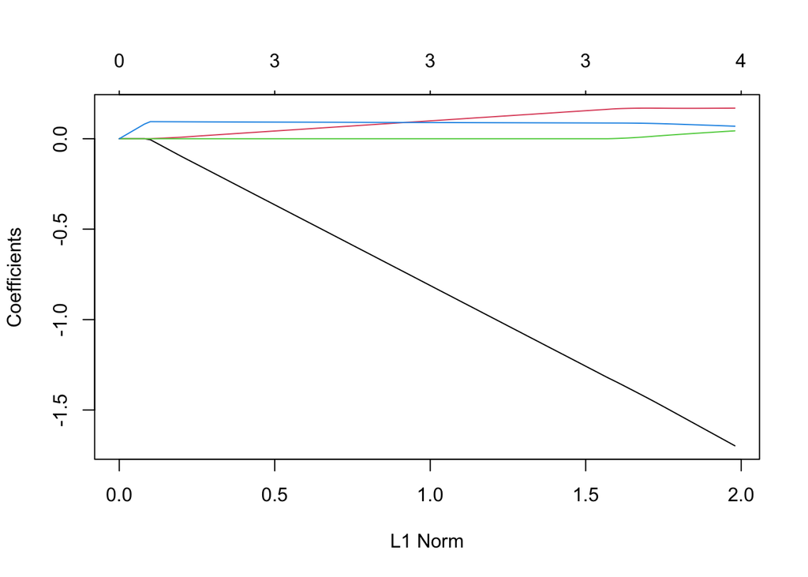

```r
s1 <- liefer %>% filter(!is.na(cells), !is.na(rna), replicate == "B",
                        species == "Thalassiosira pseudonana")
X <- s1[, c("c", "n", "p", "rna", "protein", "chl_a", "total_pigments")] %>% as.matrix()
X <- s1 %>% ungroup() %>% select(c, n, p, rna, protein, dna, chl_a, total_pigments) %>%
  mutate(log_n_c = log(n/c),
         log_n_p = log(n/p),
         log_n_rna = log(n/rna),
         log_n_protein = log(n/protein),
         log_n_dna = log(n/dna),
         log_n_chl_a = log(n/chl_a),
         log_rna_pro = log(rna/protein),
         log_rna_dna = log(rna/dna),
         log_chla_dna = log(chl_a/dna)) %>% as.matrix()
m1 <- glmnet(X,
             s1 %>% pull(derivative), # pull(growth_rate),
             family = "gaussian",
             alpha = 1 # lasso
             )
plot(m1)
```

```r
coef(m1, s = 0.01)
```

```
## 18 x 1 sparse Matrix of class "dgCMatrix"
##                          1
## (Intercept)     0.98093178
## c               .
## n               .
## p               .
## rna             .
## protein         .
## dna            -1.69777526
## chl_a           .
## total_pigments  .
## log_n_c         0.16913894
## log_n_p         .
## log_n_rna       .
## log_n_protein   .
## log_n_dna       0.04357602
## log_n_chl_a     .
## log_rna_pro     .
## log_rna_dna     0.06924274
## log_chla_dna    .
```

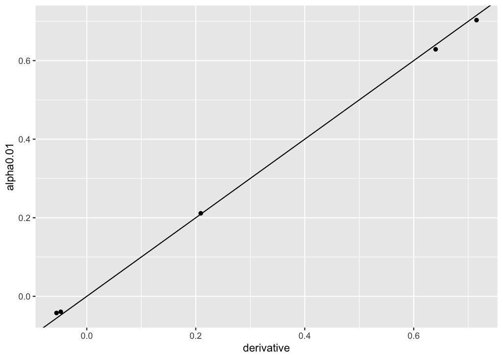

```r
pr1 <- predict(m1, newx = X,
        s = c(0.01, 0.1)) %>% as_tibble()
names(pr1) <- c("alpha0.01", "alpha0.1")
bind_cols(s1, pr1) %>% ggplot(aes(x = derivative)) +  # growth_rate)) +
  # geom_point(aes(y = alpha0.1), color = "blue") +
  geom_point(aes(y = alpha0.01)) +
  geom_abline(aes(intercept = 0, slope = 1))
```

# Calculation for 3 replicates, one species at a time

Add a constant for replicates B and C but use same coefficients for all replicates.

```r
glmF <- function(spp = "Thalassiosira pseudonana") {
  s1 <- liefer %>% filter(!is.na(cells), !is.na(rna),
                        species == spp)
  # X <- s1[, c("n", "p", "rna", "protein")] %>% as.matrix()
  X <- s1 %>% ungroup() %>%
    mutate(# RepA = 0 + (replicate == "A"),
         RepB = 0 + (replicate == "B"),
         RepC = 0 + (replicate == "C")) %>%
    select(RepB, RepC, c, n, p, rna, protein, dna, chl_a, total_pigments) %>%
    mutate(  log_n_c = log(n/c),
         log_n_p = log(n/p),
         log_n_rna = log(n/rna),
         log_n_protein = log(n/protein),
         log_n_dna = log(n/dna),
         log_n_chl_a = log(n/chl_a),
         log_rna_pro = log(rna/protein),
         log_rna_dna = log(rna/dna),
         log_chla_dna = log(chl_a/dna)) %>%
    # select(-c, -n, -p, -rna, -protein, -dna, -chl_a, -total_pigments) %>%
    as.matrix()
  m1 <- glmnet(X,
            s1 %>% pull(derivative), #  pull(growth_rate),
             family = "gaussian",
             alpha = 1 # lasso
             )
  # plot(m1)
  pr1 <- predict(m1, newx = X,
        s = c(0.01, 0.001)) %>% as_tibble()
  names(pr1) <- c("alpha0.01", "alpha0.001")
  bind_cols(s1, pr1) %>% mutate(spp = spp) %>% ggplot(aes(x = derivative)) + # growth_rate)) +
    geom_point(aes(y = alpha0.001), color = "blue") +
    # geom_point(aes(y = alpha0.01)) +
    geom_abline(aes(intercept = 0, slope = 1)) +
    labs(x = "Observed (estimated) growth rate",
         y = "Predicted growth rate",
         title = spp) -> p1
  list(plot = p1, coef = coef(m1, s = 0.001))
}
```

## Predicted vs observed

This looks like a pretty good match up between predicted and observed growth rate.

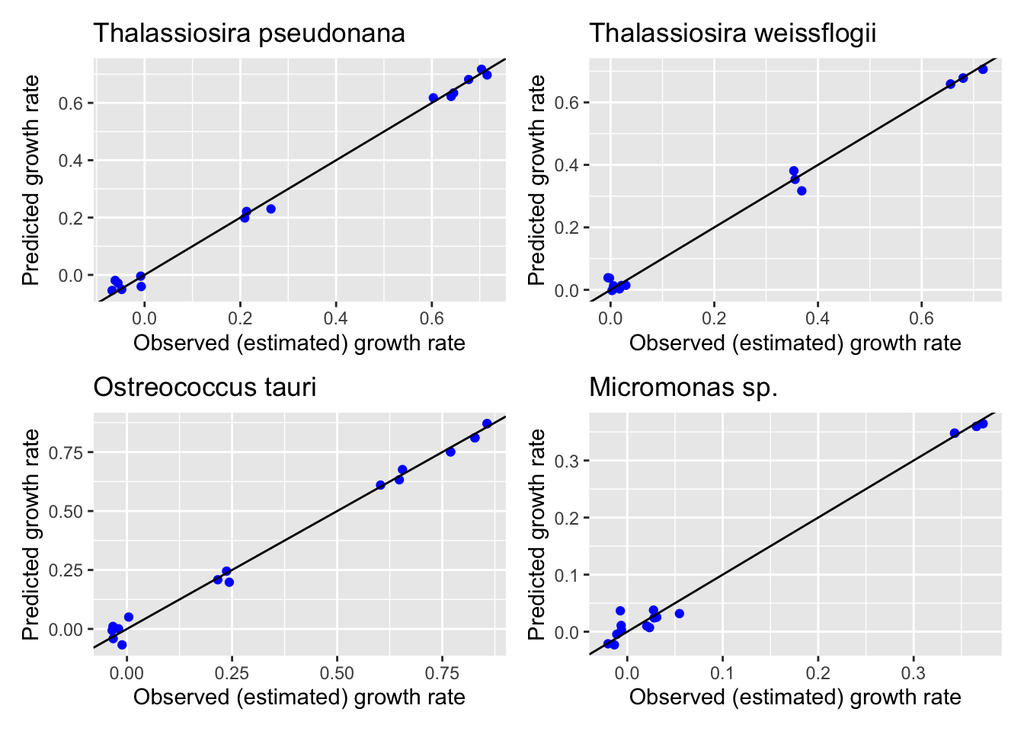

```r
m1 <- glmF()
m2 <- glmF("Thalassiosira weissflogii")
m3 <- glmF("Ostreococcus tauri")
m4 <- glmF("Micromonas sp.")
(m1$plot + m2$plot) / (m3$plot + m4$plot)
```

## Coefficients

```r
t1 <- cbind(m1$coef, m2$coef, m3$coef, m4$coef)
colnames(t1) = c("T. pseudonana", "T. weissflogii", "O. tauri", "Micromonas sp.")
t1a <- t1 %>% as.matrix()
t1a[t1a == 0] <- NA
opts <- options(knitr.kable.NA = "")
t1a %>% knitr::kable(digits = 3) %>% kable_styling(full_width = FALSE, bootstrap_options = "striped")
```

|  | T. pseudonana | T. weissflogii | O. tauri | Micromonas sp. |
| --- | --- | --- | --- | --- |
| (Intercept) | 0.800 | 0.250 | -0.503 | -0.054 |
| RepB | 0.013 | -0.009 | 0.004 |  |
| RepC | 0.040 | -0.006 |  | 0.003 |
| c |  |  |  | -0.149 |
| n |  |  |  |  |
| p | 0.065 | 0.063 |  | 6.973 |
| rna | 0.044 |  | 14.779 |  |
| protein |  | 0.002 | 1.741 |  |
| dna | -1.571 |  |  | -2.862 |
| chl_a | 0.156 |  | 17.699 |  |
| total_pigments |  |  | 6.145 |  |
| log_n_c | 0.101 | 0.218 |  |  |
| log_n_p |  |  | 0.019 |  |
| log_n_rna | -0.072 |  |  |  |
| log_n_protein |  |  |  |  |
| log_n_dna |  | 0.039 |  | 0.364 |
| log_n_chl_a |  | 0.131 |  | 0.060 |
| log_rna_pro |  |  |  | 0.091 |
| log_rna_dna | 0.082 |  | 0.024 | 0.016 |
| log_chla_dna |  |  | 0.020 |  |

# Re-do without “quotas”

```r
glmF <- function(spp = "Thalassiosira pseudonana") {
  s1 <- liefer %>% filter(!is.na(cells), !is.na(rna),
                        species == spp)
  # X <- s1[, c("n", "p", "rna", "protein")] %>% as.matrix()
  X <- s1 %>% ungroup() %>%
    mutate(# RepA = 0 + (replicate == "A"),
         RepB = 0 + (replicate == "B"),
         RepC = 0 + (replicate == "C")) %>%
    select(RepB, RepC, c, n, p, rna, protein, dna, chl_a, total_pigments) %>%
    mutate( #  log_n_c = log(n/c),
         # log_n_p = log(n/p),
         log_n_rna = log(n/rna),
         log_n_protein = log(n/protein),
         log_n_dna = log(n/dna),
         log_n_chl_a = log(n/chl_a),
         log_rna_pro = log(rna/protein),
         log_rna_dna = log(rna/dna),
         log_chla_dna = log(chl_a/dna)) %>%
    select(-c, -n, -p, -rna, -protein, -dna, -chl_a, -total_pigments) %>%
    as.matrix()
  m1 <- glmnet(X,
            s1 %>% pull(derivative), #  pull(growth_rate),
             family = "gaussian",
             alpha = 1 # lasso
             )
  # plot(m1)
  pr1 <- predict(m1, newx = X,
        s = c(0.01, 0.001)) %>% as_tibble()
  names(pr1) <- c("alpha0.01", "alpha0.001")
  bind_cols(s1, pr1) %>% mutate(spp = spp) %>% ggplot(aes(x = derivative)) + # growth_rate)) +
    geom_point(aes(y = alpha0.001), color = "blue") +
    # geom_point(aes(y = alpha0.01)) +
    geom_abline(aes(intercept = 0, slope = 1)) +
    labs(x = "Observed (estimated) growth rate",
         y = "Predicted growth rate",
         title = spp) -> p1
  list(plot = p1, coef = coef(m1, s = 0.001))
}
```

## Predicted vs observed

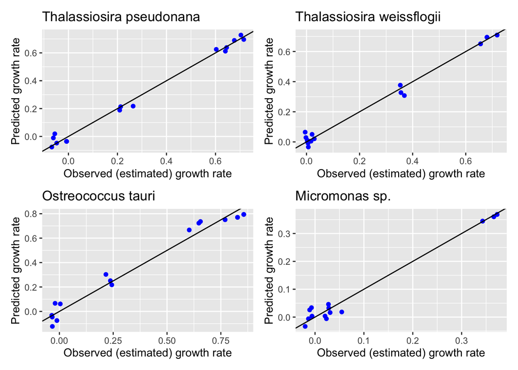

```r
m1 <- glmF()
m2 <- glmF("Thalassiosira weissflogii")
m3 <- glmF("Ostreococcus tauri")
m4 <- glmF("Micromonas sp.")
(m1$plot + m2$plot) / (m3$plot + m4$plot)
```

## Coefficients

```r
t1 <- cbind(m1$coef, m2$coef, m3$coef, m4$coef)
colnames(t1) = c("T. pseudonana", "T. weissflogii", "O. tauri", "Micromonas sp.")
t1a <- t1 %>% as.matrix()
t1a[t1a == 0] <- NA
opts <- options(knitr.kable.NA = "")
t1a %>% knitr::kable(digits = 3) %>% kable_styling(full_width = FALSE, bootstrap_options = "striped")
```

|  | T. pseudonana | T. weissflogii | O. tauri | Micromonas sp. |
| --- | --- | --- | --- | --- |
| (Intercept) | -0.058 | -1.965 | 1.358 | 0.309 |
| RepB | 0.000 | -0.030 | -0.035 |  |
| RepC | 0.035 | -0.021 | -0.009 |  |
| log_n_rna |  |  | -0.268 |  |
| log_n_protein | -0.025 | -0.314 |  | 0.001 |
| log_n_dna | 0.030 | 0.851 |  | 0.288 |
| log_n_chl_a |  | 0.062 |  | 0.005 |
| log_rna_pro |  | -0.019 | 0.074 | 0.120 |
| log_rna_dna | 0.202 |  | 0.125 | 0.016 |
| log_chla_dna | 0.137 |  | 0.528 | 0.248 |

# Better choices

Drop all elemental ratios. Just macromolecules.

Use cv.glmnet to select lambda.

```r
glmF <- function(spp = "Thalassiosira pseudonana") {
  s1 <- liefer %>% filter(!is.na(cells), !is.na(rna),
                        species == spp)
  # X <- s1[, c("n", "p", "rna", "protein")] %>% as.matrix()
  X <- s1 %>% ungroup() %>%
    mutate(# RepA = 0 + (replicate == "A"),
         RepB = 0 + (replicate == "B"),
         RepC = 0 + (replicate == "C")) %>%
    select(RepB, RepC, rna, protein, dna, chl_a, total_pigments) %>%
    mutate(
         log_rna_pro = log(rna/protein),
         log_rna_dna = log(rna/dna),
         log_rna_chl_a = log(rna/chl_a),
         # log_rna_pigment = log(rna/total_pigments),
         log_protein_dna = log(protein/dna),
         log_protein_chla = log(protein/chl_a),
         # log_protein_pigment = log(protein/total_pigments),
         # log_chla_pigment = log(chl_a/total_pigments),
         log_chla_dna = log(chl_a/dna)) %>%
    select(-rna, -protein, -dna, -chl_a, -total_pigments) %>%
    as.matrix()
  m1 <- cv.glmnet(X,
            s1 %>% pull(derivative), #  pull(growth_rate),
             family = "gaussian",
             alpha = 1 # lasso
             )
  # plot(m1)
  pr1 <- predict(m1, newx = X, s = "lambda.1se") %>% as_tibble()
  names(pr1) <- c("1se")
  bind_cols(s1, pr1) %>% mutate(spp = spp) %>% ggplot(aes(x = derivative)) + # growth_rate)) +
    geom_point(aes(y = `1se`), color = "blue") +
    # geom_point(aes(y = alpha0.01)) +
    geom_abline(aes(intercept = 0, slope = 1)) +
    labs(x = "Observed (estimated) growth rate",
         y = "Predicted growth rate",
         title = spp) -> p1
  list(plot = p1, coef = coef(m1, s = "lambda.1se"))
}
```

## Predicted vs observed

```r
m1 <- glmF()
m2 <- glmF("Thalassiosira weissflogii")
m3 <- glmF("Ostreococcus tauri")
m4 <- glmF("Micromonas sp.")
```

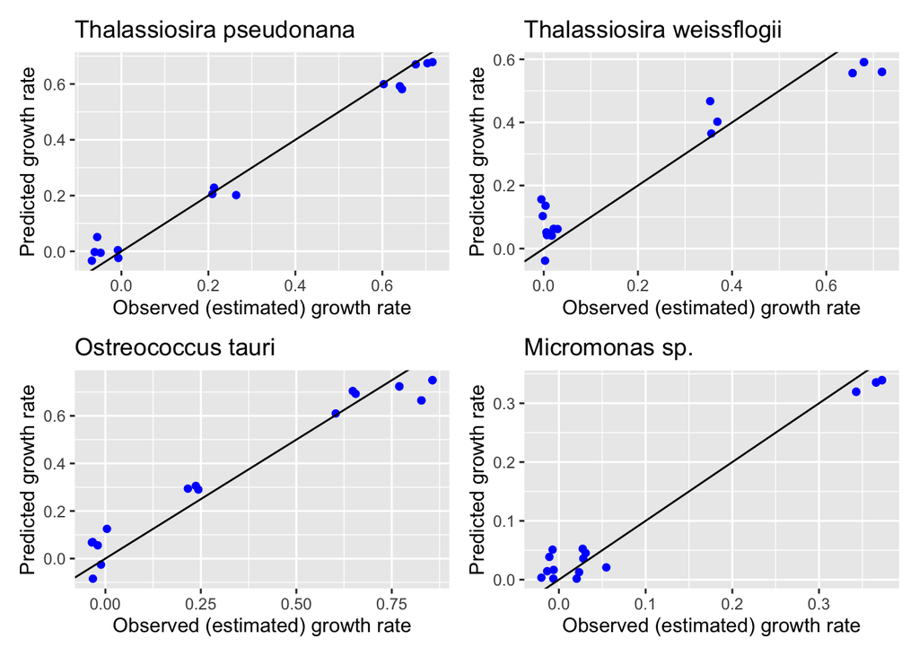

```r
(m1$plot + m2$plot) / (m3$plot + m4$plot)
```

## Coefficients

```r
t1 <- cbind(m1$coef, m2$coef, m3$coef, m4$coef)
colnames(t1) = c("T. pseudonana", "T. weissflogii", "O. tauri", "Micromonas sp.")
t1a <- t1 %>% as.matrix()
t1a[t1a == 0] <- NA
opts <- options(knitr.kable.NA = "")
t1a %>% knitr::kable(digits = 3) %>% kable_styling(full_width = FALSE, bootstrap_options = "striped")
```

|  | T. pseudonana | T. weissflogii | O. tauri | Micromonas sp. |
| --- | --- | --- | --- | --- |
| (Intercept) | -0.009 | -2.337 | 0.502 | 0.361 |
| RepB |  |  |  |  |
| RepC |  |  |  |  |
| log_rna_pro |  |  |  |  |
| log_rna_dna | 0.209 | 0.027 | 0.356 | 0.143 |
| log_rna_chl_a |  | 0.062 |  |  |
| log_protein_dna | 0.022 | 0.744 |  |  |
| log_protein_chla |  |  |  |  |
| log_chla_dna | 0.107 |  |  | 0.352 |